# Title of the document

Gianandrea La Porta

4/27/2020

## 0.1 R Markdown

## 0.2 Including Plots

# 1 chapter basics

## 1.1 Tasks

Large number of tasks:

- create notebook, in which you can run R code
- make slide for presentations
- write journal articles
- authoring books (e.g. phD thesis)
- generate website or blogs

## 1.2 Text formats

- *italics*
- **bold text**
- H<sub>3</sub>PO<sub>4</sub>
- Cu<sup>2+</sup>
- $\pi$

### 1.2.1 Chunk for R code

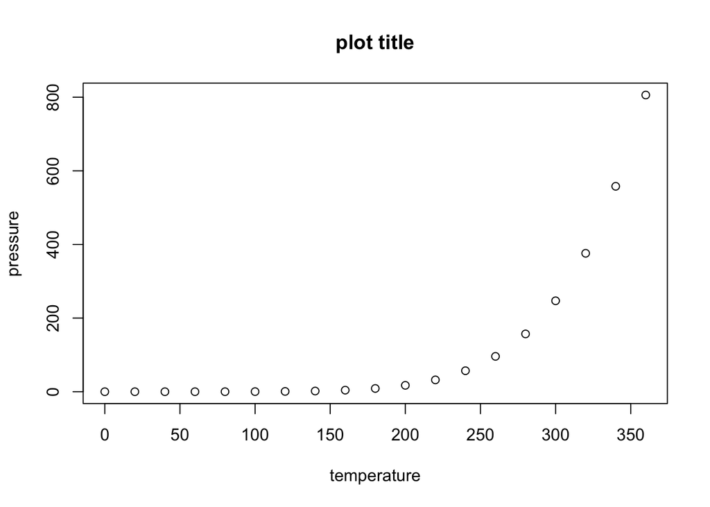

Figure 1.1: This is the figure caption

```r
plot(pressure, main='plot title')
```

```r
library(bookdown)
```

As you can see in fig. 1.1.

### 1.2.2 Resources

https://rmarkdown.rstudio.com/lesson-1.html https://bookdown.org/yihui/rmarkdown-cookbook/

# 2 New topic

ifelse(test_expression,x,y)

```r
ob <- 6
ifelse(ob==3,'Ok','Bad')
```

```
## [1] "Bad"
```

# 3 CLUSTER ANALYSIS $\alpha$

The goal of the cluster analysis is to identify groups…

```r
library(vegan)
data("varechem")
varechem
```

```
##       N    P     K     Ca    Mg    S    Al    Fe    Mn   Zn   Mo Baresoil
## 18 19.8 42.1 139.9  519.4  90.0 32.3  39.0  40.9  58.1  4.5 0.30    43.90
## 15 13.4 39.1 167.3  356.7  70.7 35.2  88.1  39.0  52.4  5.4 0.30    23.60
## 24 20.2 67.7 207.1  973.3 209.1 58.1 138.0  35.4  32.1 16.8 0.80    21.20
## 27 20.6 60.8 233.7  834.0 127.2 40.7  15.4   4.4 132.0 10.7 0.20    18.70
## 23 23.8 54.5 180.6  777.0 125.8 39.5  24.2   3.0  50.1  6.6 0.30    46.00
## 19 22.8 40.9 171.4  691.8 151.4 40.8 104.8  17.6  43.6  9.1 0.40    40.50
## 22 26.6 36.7 171.4  738.6  94.9 33.8  20.7   2.5  77.6  7.4 0.30    23.00
## 16 24.2 31.0 138.2  394.6  45.3 27.1  74.2   9.8  24.4  5.2 0.30    29.80
## 28 29.8 73.5 260.0  748.6 105.3 42.5  17.9   2.4 106.6  9.3 0.30    17.60
## 13 28.1 40.5 313.8  540.7 118.9 60.2 329.7 109.9  61.7  9.1 0.50    29.90
## 14 21.8 38.1 146.8  512.2  75.0 36.6  92.3   4.6  29.0  8.1 0.50    33.30
## 20 26.2 61.9 202.2  741.2  86.3 48.6 124.3  23.6  94.5 10.2 0.60    56.90
## 25 22.8 50.6 151.7  648.0  64.8 30.2  12.1   2.3 122.9  8.1 0.20    23.70
## 7  30.5 24.6  78.7  188.5  55.5 25.3 294.9 123.8  10.1  3.0 0.40    18.60
```

[output cut: 35 more lines]

## 3.1 Distance methods

Calculation of distance matrix with dist(). This function computes and returns the distance matrix computed by using the specified distance measure to compute the distances between the rows of a data matrix.

The distance can be measured with:

- “euclidean”,
- “maximum”,
- “manhattan”,
- …

```r
varechem.st <- scale(varechem)
# method = 'euclidean'
varechem.dist <- dist(varechem.st, method = 'euclidean')
round(varechem.dist,2)
```

```
##      18   15   24   27   23   19   22   16   28   13   14   20   25    7    5
## 15 2.08
## 24 6.88 6.90
## 27 4.47 4.64 5.48
## 23 2.51 3.73 5.71 3.49
## 19 3.58 4.23 5.44 3.96 2.09
## 22 2.66 3.32 6.21 3.14 2.35 2.92
## 16 2.30 2.52 7.58 5.60 3.84 4.54 3.04
## 28 4.71 5.14 5.73 2.25 3.38 4.17 3.20 5.43
## 13 5.16 5.14 5.50 5.18 4.83 4.70 4.78 5.54 4.79
## 14 2.21 2.51 6.05 4.55 2.61 2.80 2.42 2.22 4.50 4.68
## 20 3.93 4.72 5.14 3.71 3.08 3.79 3.60 4.92 3.39 4.08 3.68
## 25 3.13 3.44 6.82 2.70 3.40 4.23 2.13 3.77 3.21 5.63 3.51 3.68
## 7  4.90 4.85 8.77 7.83 6.34 6.53 5.47 3.67 7.43 6.14 4.89 6.73 6.07
## 5  5.49 5.50 9.04 7.61 6.78 7.28 5.34 3.76 7.35 7.71 5.30 7.19 5.55 3.96
## 6  4.24 3.52 8.34 7.13 5.99 6.16 4.96 3.09 7.17 6.72 4.06 6.60 5.29 2.89 4.04
## 3  6.11 5.87 9.11 8.44 7.37 7.48 6.45 5.16 7.98 6.71 6.11 7.51 6.86 2.01 5.01
## 4  6.06 5.49 5.68 6.71 6.29 6.30 6.36 6.19 6.42 4.33 5.23 4.98 6.61 6.42 8.12
## 2  4.95 4.27 6.95 6.36 5.93 6.14 5.33 4.67 6.21 4.45 4.87 5.96 5.63 3.98 5.86
## 9  4.21 3.15 5.30 5.18 4.74 4.68 4.29 4.11 5.40 4.82 3.22 4.63 4.56 5.12 5.99
## 12 2.86 1.75 6.86 5.24 4.17 4.45 3.30 2.13 5.54 5.62 2.37 5.21 3.81 4.25 4.59
## 10 4.97 4.12 5.53 4.71 5.19 5.91 4.95 5.21 5.16 5.26 5.09 5.34 4.74 6.43 6.61
## 11 6.56 6.16 6.31 6.46 6.61 7.13 6.31 6.65 6.85 6.55 6.74 6.70 6.39 6.84 7.40
## 21 2.54 3.35 7.84 5.89 3.75 4.30 3.59 2.40 6.11 6.43 3.03 5.03 4.14 4.64 4.84
##       6    3    4    2    9   12   10   11
## 15
## 24
## 27
## 23
## 19
## 22
## 16
## 28
## 13
## 14
## 20
## 25
## 7
## 5
## 6
## 3  3.64
## 4  6.02 6.61
## 2  4.26 3.94 4.59
## 9  3.83 5.63 3.55 3.91
## 12 2.56 5.30 5.55 4.28 2.66
## 10 5.89 6.83 5.61 4.39 3.85 4.28
## 11 6.82 6.80 6.83 5.39 5.57 5.87 3.34
## 21 4.23 6.05 7.24 6.02 5.08 3.28 5.89 6.74
```

Create an image of dist matrix

```r
varechem.dist.m <- as.matrix(varechem.dist)
dim(varechem.dist.m)
```

```
## [1] 24 24
```

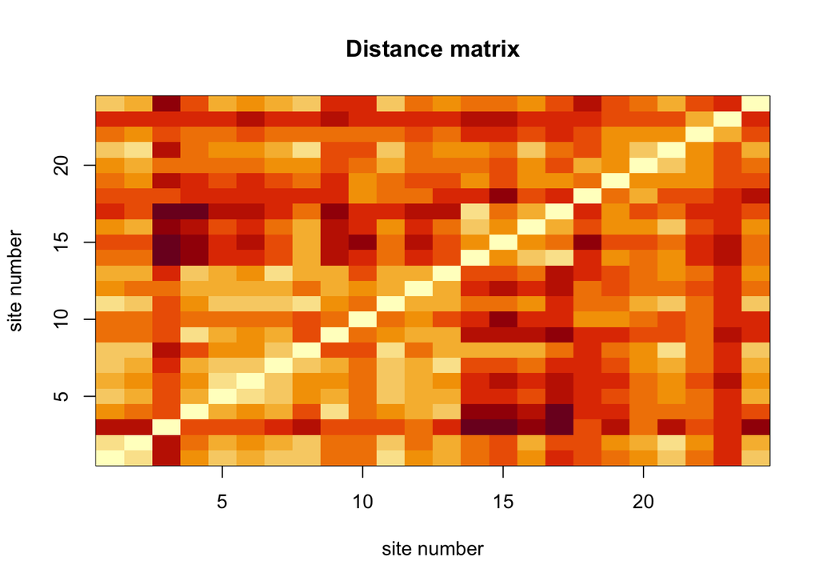

```r
image(1:24,1:24,varechem.dist.m,
      xlab = 'site number',
      ylab = 'site number',
      main='Distance matrix')
```

## 3.2 Hierarchical cluster analysis

Hierarchical cluster analysis on a set of dissimilarities and methods for analyzing it.

Methods: - “ward.D”, - “ward.D2”, - “single”, - “complete”, - “average” (= UPGMA) - …

```r
vare.clust <- hclust(varechem.dist, method = 'complete')
vare.clust
```

```
##
## Call:
## hclust(d = varechem.dist, method = "complete")
##
## Cluster method   : complete
## Distance         : euclidean
## Number of objects: 24
```

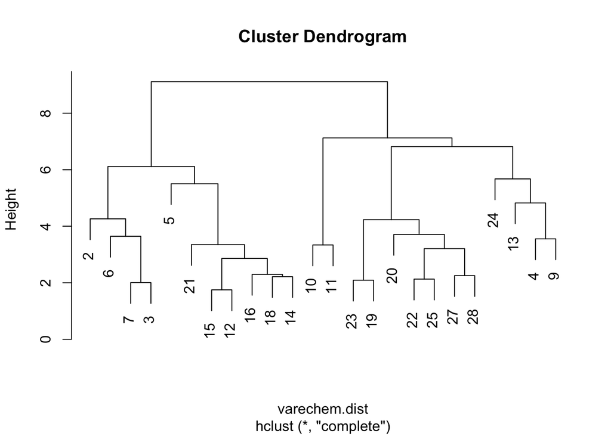

```r
plot(vare.clust)
```

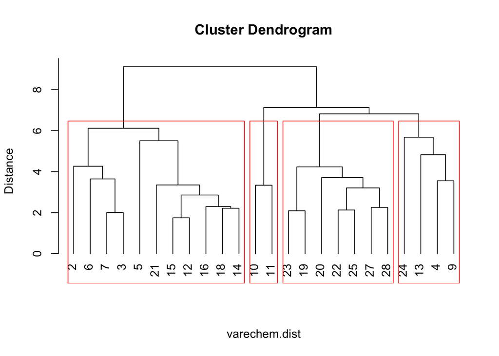

```r
plot(vare.clust, ylab='Distance', sub='', hang = -1)
rect.hclust(vare.clust, k=4, border = 'red')
```

```r
#install.packages("factoextra")
library(factoextra)
```

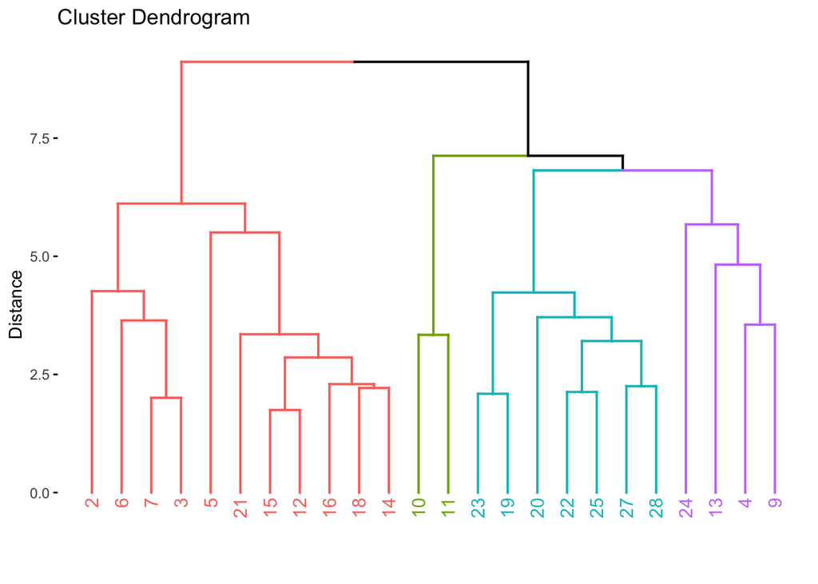

```r
fviz_dend(vare.clust, k=4, y='Distance')
```

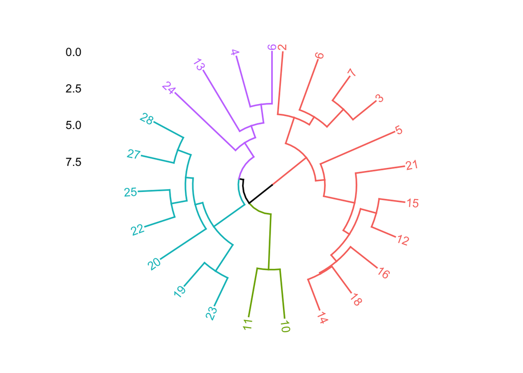

```r
fviz_dend(vare.clust, k=4, y='Distance', type = 'circ')
```

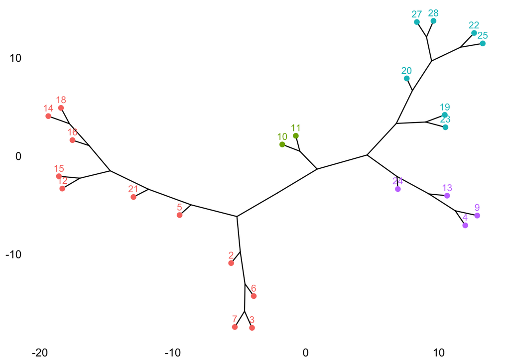

```r
fviz_dend(vare.clust, k=4, y='Distance', type = 'phyl')
```

### 3.2.1 Challange

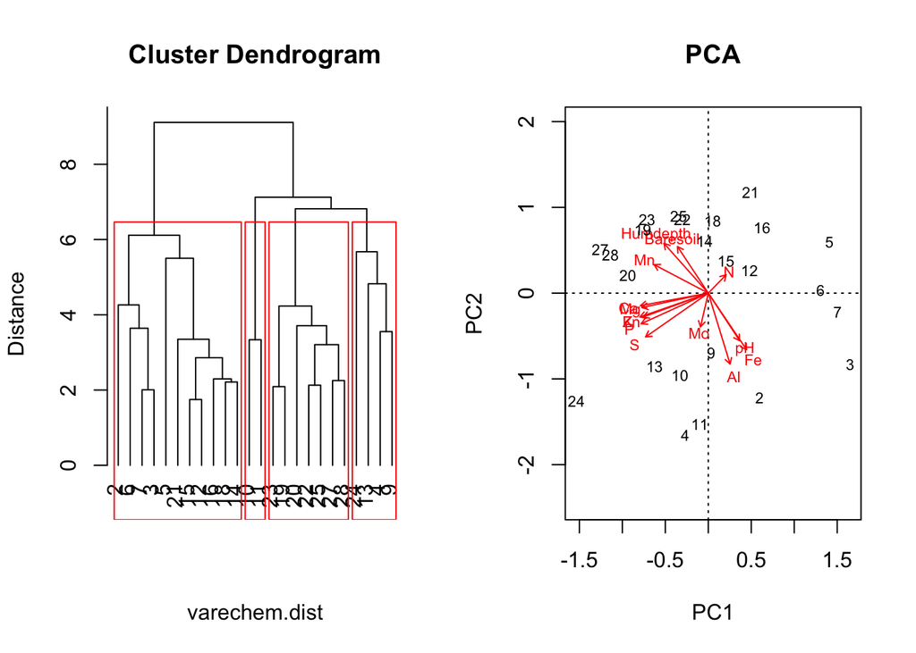

```r
par(mfrow=c(1,2))
# cluster
plot(vare.clust, ylab='Distance', sub='', hang = -1)
rect.hclust(vare.clust, k=4, border = 'red')

# PCA biplot
biplot(rda(varechem,scale = T), main='PCA')
```

# 4 ChemoSpec

An R Package for Chemometric Analysis of Spectra (NMR, IR etc).

Import data: - files2SpectraObject() - matrix2SpectraObject()

```r
library(ChemoSpec)
data("SrE.IR")
SrE.IR
```

```
## $freq
##    [1]  399.2123  401.1409  403.0695  404.9980  406.9266  408.8552  410.7837
##    [8]  412.7123  414.6408  416.5694  418.4980  420.4265  422.3551  424.2837
##   [15]  426.2122  428.1408  430.0693  431.9979  433.9265  435.8550  437.7836
##   [22]  439.7121  441.6407  443.5693  445.4978  447.4264  449.3549  451.2835
##   [29]  453.2121  455.1406  457.0692  458.9978  460.9263  462.8549  464.7834
##   [36]  466.7120  468.6406  470.5691  472.4977  474.4263  476.3548  478.2834
##   [43]  480.2119  482.1405  484.0691  485.9976  487.9262  489.8548  491.7833
##   [50]  493.7119  495.6404  497.5690  499.4976  501.4261  503.3547  505.2832
##   [57]  507.2118  509.1404  511.0689  512.9975  514.9261  516.8546  518.7832
##   [64]  520.7117  522.6403  524.5688  526.4974  528.4260  530.3546  532.2831
##   [71]  534.2117  536.1403  538.0688  539.9974  541.9259  543.8545  545.7830
##   [78]  547.7116  549.6402  551.5687  553.4973  555.4258  557.3544  559.2830
##   [85]  561.2115  563.1401  565.0687  566.9973  568.9258  570.8544  572.7829
##   [92]  574.7115  576.6400  578.5686  580.4972  582.4257  584.3543  586.2828
```

[output cut: 5691 more lines]

```r
sumSpectra(SrE.IR)
```

```
##
##  Serenoa repens IR quality study
##
##  There are 16 spectra in this set.
##  The y-axis unit is absorbance.
##
##  The frequency scale runs from
##  399.2123 to 3999.837 wavenumber
##  There are 1868 frequency values.
##  The frequency resolution is
##  1.9286 wavenumber/point.
##
##
##  The spectra are divided into 4 groups:
##
##   group no.   color symbol alt.sym
## 1 adSrE  10 #984EA3     15       d
## 2   EPO   1 #377EB8      2       b
## 3    OO   1 #4DAF4A      3       c
## 4  pSrE   4 #E41A1C      1       a
##
##
## *** Note: this is an S3 object
## of class 'Spectra'
```

```r
SrE.IR$names
```

```
##  [1] "CVS_adSrE" "ET_pSrE"   "GNC_adSrE" "LF_adSrE"  "MDB_pSrE"  "NA_pSrE"
##  [7] "Nat_adSrE" "NP_adSrE"  "NR_pSrE"   "NSI_adSrE" "NW_adSrE"  "SN_adSrE"
## [13] "Sol_adSrE" "SV_EPO"    "TD_adSrE"  "TJ_OO"
```

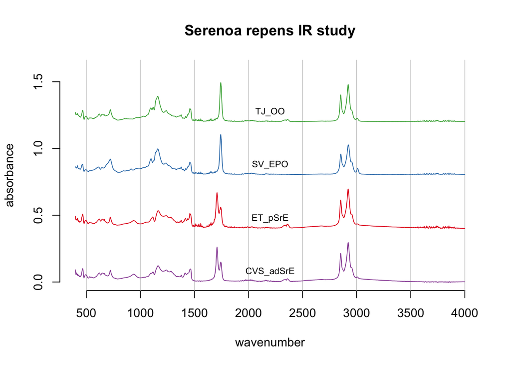

```r
plotSpectra(SrE.IR,
     main='Serenoa repens IR study',
     which=c(1,2,14,16),
     yrange=c(0,1.6),
     offset = 0.4,
     lab.pos=2200)
```

## 4.1 Data pre-Processing

1. baseline correction
2. data normalizaion
3. scale the data
4. bin the data

```r
SrE.IR2 <- baselineSpectra(SrE.IR, int=F,
                           method='modpolyfit', retC = T)
```

[figure not shown]

```r
HCA <- hcaSpectra(SrE.IR2,
           c.method = 'complete',
           d.method = 'euclidean',
           main='Cluster')
```

[figure not shown]

# 5 PCA on Spectra

- classical methods - c_pcaSpectra()
- robust methods -r_pcaSpectra()

```r
c_res <- c_pcaSpectra(SrE.IR2, choice = 'noscale')
c_res
```

```
## Standard deviations (1, .., p=16):
##  [1] 3.943894e-01 7.533392e-02 6.054416e-02 3.992531e-02 3.507298e-02
##  [6] 2.390030e-02 2.302436e-02 1.649838e-02 1.474047e-02 1.337592e-02
## [11] 1.088635e-02 7.886062e-03 7.439990e-03 6.841655e-03 5.560516e-03
## [16] 1.242086e-16
##
## Rotation (n x k) = (1868 x 16):
##                   PC1           PC2           PC3           PC4           PC5
##    [1,] -3.519596e-03 -7.260783e-02  3.339141e-03  3.028142e-02 -8.830833e-02
##    [2,]  2.992280e-03 -4.069311e-02  8.801071e-03  3.657657e-02 -1.293738e-01
##    [3,]  3.213544e-03 -3.450178e-02  6.611618e-03  2.301017e-02 -1.101253e-01
##    [4,]  1.478593e-06 -4.894809e-02  2.912916e-02 -1.255635e-03 -3.758236e-02
##    [5,] -6.321118e-04 -4.843542e-02  2.352518e-02 -8.253658e-03 -4.927458e-02
##    [6,]  4.595525e-03 -3.119370e-02  8.341006e-03 -1.966769e-02 -7.209265e-02
##    [7,]  5.792390e-03 -3.104906e-02  1.990829e-02 -1.944784e-02 -2.283541e-02
```

[output cut: 7468 more lines]

```r
summary(c_res)
```

```
## Importance of components:
##                           PC1     PC2     PC3     PC4     PC5     PC6     PC7
## Standard deviation     0.3944 0.07533 0.06054 0.03993 0.03507 0.02390 0.02302
## Proportion of Variance 0.9161 0.03342 0.02159 0.00939 0.00724 0.00336 0.00312
## Cumulative Proportion  0.9161 0.94951 0.97110 0.98048 0.98773 0.99109 0.99422
##                           PC8     PC9    PC10    PC11     PC12    PC13     PC14
## Standard deviation     0.0165 0.01474 0.01338 0.01089 0.007886 0.00744 0.006842
## Proportion of Variance 0.0016 0.00128 0.00105 0.00070 0.000370 0.00033 0.000280
## Cumulative Proportion  0.9958 0.99710 0.99815 0.99885 0.999220 0.99954 0.999820
##                            PC15      PC16
## Standard deviation     0.005561 1.242e-16
## Proportion of Variance 0.000180 0.000e+00
## Cumulative Proportion  1.000000 1.000e+00
```

Plot the scores

```r
plotScores(SrE.IR2, c_res, pcs = c(1, 2),
           ellipse='cls', tol=1,
           main='Classical method')
```

```
## Group EPO
##  has only 1 member (no ellipse possible)
```

```
## Group OO
##  has only 1 member (no ellipse possible)
```

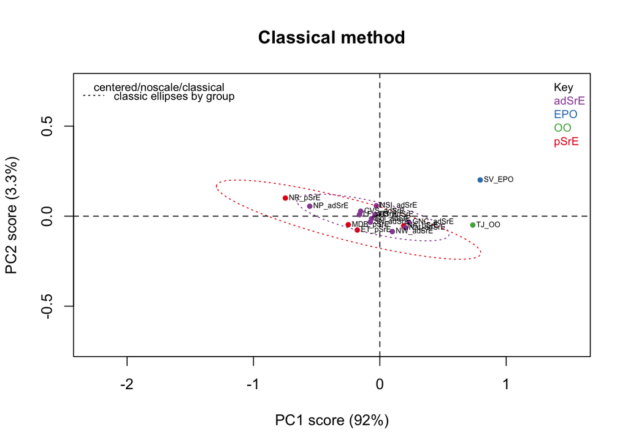

```r
abline(h=0,v=0,lty=2)
```